# Gas Cost Estimator: comparison of obtained estimates, alternative gas cost schedule

Parametrization. The comma separeted list of csv files with precomputed estimated costs for evm clients estimate_files=reports-12.01.2025/estimated_cost_marginal_create_besu.csv,reports-12.01.2025/estimated_cost_marginal_create_erigon.csv,reports-12.01.2025/estimated_cost_marginal_create_ethereumjs.csv,reports-12.01.2025/estimated_cost_marginal_create_evmone.csv,reports-12.01.2025/estimated_cost_marginal_create_geth.csv,reports-12.01.2025/estimated_cost_marginal_create_nethermind.csv,reports-12.01.2025/estimated_cost_marginal_create_revm.csv,reports-12.01.2025/estimated_cost_marginal_full_besu.csv,reports-12.01.2025/estimated_cost_marginal_full_erigon.csv,reports-12.01.2025/estimated_cost_marginal_full_ethereumjs.csv,reports-12.01.2025/estimated_cost_marginal_full_evmone.csv,reports-12.01.2025/estimated_cost_marginal_full_geth.csv,reports-12.01.2025/estimated_cost_marginal_full_nethermind.csv,reports-12.01.2025/estimated_cost_marginal_full_revm.csv,reports-12.01.2025/estimated_cost_marginal_mem_besu.csv,reports-12.01.2025/estimated_cost_marginal_mem_erigon.csv,reports-12.01.2025/estimated_cost_marginal_mem_ethereumjs.csv,reports-12.01.2025/estimated_cost_marginal_mem_evmone.csv,reports-12.01.2025/estimated_cost_marginal_mem_geth.csv,reports-12.01.2025/estimated_cost_marginal_mem_nethermind.csv,reports-12.01.2025/estimated_cost_marginal_mem_revm.csv,reports-12.01.2025/estimated_cost_marginal_precompiles_full_besu.csv,reports-12.01.2025/estimated_cost_marginal_precompiles_full_erigon.csv,reports-12.01.2025/estimated_cost_marginal_precompiles_full_evmone.csv,reports-12.01.2025/estimated_cost_marginal_precompiles_full_geth.csv,reports-12.01.2025/estimated_cost_marginal_precompiles_full_nethermind.csv,reports-12.01.2025/estimated_cost_marginal_stop_besu.csv,reports-12.01.2025/estimated_cost_marginal_stop_erigon.csv,reports-12.01.2025/estimated_cost_marginal_stop_ethereumjs.csv,reports-12.01.2025/estimated_cost_marginal_stop_geth.csv,reports-12.01.2025/estimated_cost_marginal_stop_revm.csv,reports-12.01.2025/estimated_cost_marginal_t_besu.csv,reports-12.01.2025/estimated_cost_marginal_t_erigon.csv,reports-12.01.2025/estimated_cost_marginal_t_ethereumjs.csv,reports-12.01.2025/estimated_cost_marginal_t_evmone.csv,reports-12.01.2025/estimated_cost_marginal_t_geth.csv,reports-12.01.2025/estimated_cost_marginal_t_nethermind.csv,reports-12.01.2025/estimated_cost_marginal_t_revm.csv,reports-12.01.2025/estimated_cost_arguments_arithmetic_besu.csv,reports-12.01.2025/estimated_cost_arguments_arithmetic_erigon.csv,reports-12.01.2025/estimated_cost_arguments_arithmetic_ethereumjs.csv,reports-12.01.2025/estimated_cost_arguments_arithmetic_evmone.csv,reports-12.01.2025/estimated_cost_arguments_arithmetic_geth.csv,reports-12.01.2025/estimated_cost_arguments_arithmetic_nethermind.csv,reports-12.01.2025/estimated_cost_arguments_arithmetic_revm.csv,reports-12.01.2025/estimated_cost_arguments_create_besu.csv,reports-12.01.2025/estimated_cost_arguments_more_besu.csv,reports-12.01.2025/estimated_cost_arguments_more_erigon.csv,reports-12.01.2025/estimated_cost_arguments_more_ethereumjs.csv,reports-12.01.2025/estimated_cost_arguments_more_evmone.csv,reports-12.01.2025/estimated_cost_arguments_more_geth.csv,reports-12.01.2025/estimated_cost_arguments_more_nethermind.csv,reports-12.01.2025/estimated_cost_arguments_more_revm.csv,reports-12.01.2025/estimated_cost_arguments_precompiles_besu.csv,reports-12.01.2025/estimated_cost_arguments_precompiles_erigon.csv,reports-12.01.2025/estimated_cost_arguments_precompiles_ethereumjs.csv,reports-12.01.2025/estimated_cost_arguments_precompiles_evmone.csv,reports-12.01.2025/estimated_cost_arguments_precompiles_geth.csv,reports-12.01.2025/estimated_cost_arguments_precompiles_nethermind.csv,reports-12.01.2025/estimated_cost_arguments_precompiles_revm.csv, the file with the reference gas cost table and groups configuration current_gas_cost=/reports/current_gas_cost.csv, used metric code metric=l1, should the details be included in the report details=FALSE.

Plot the scaled gas cost schedules.

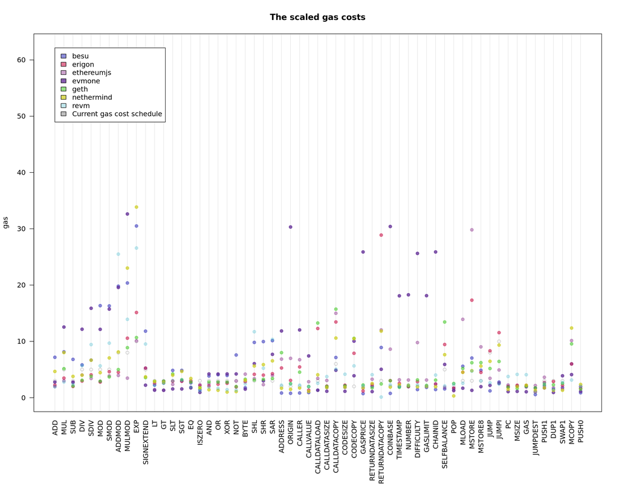

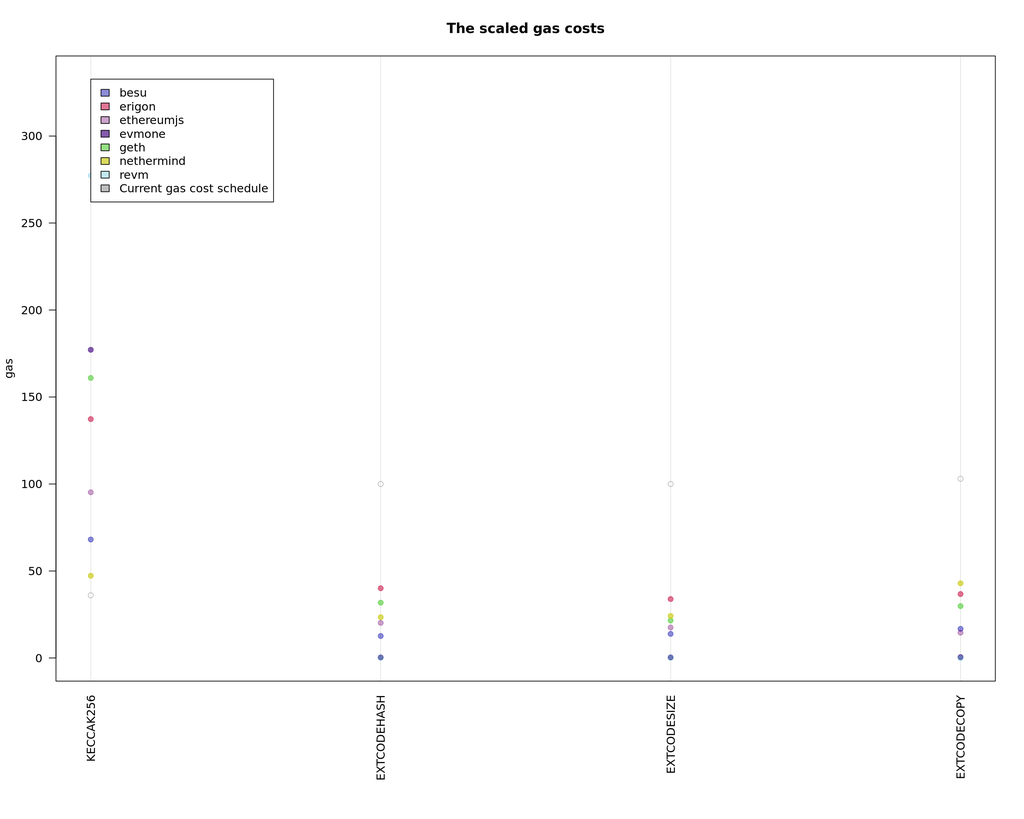

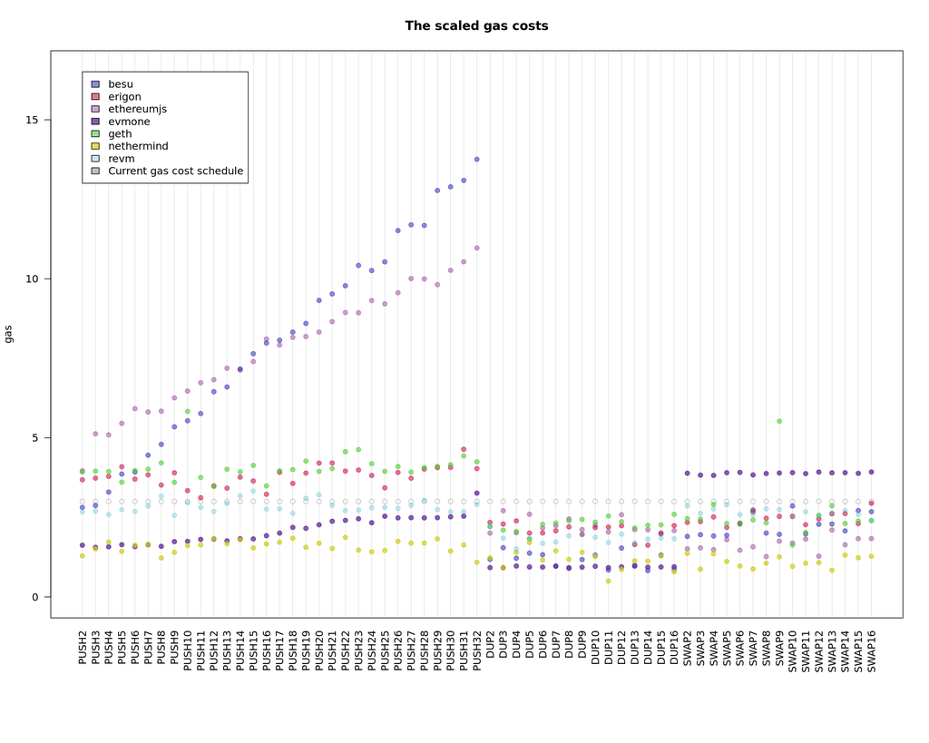

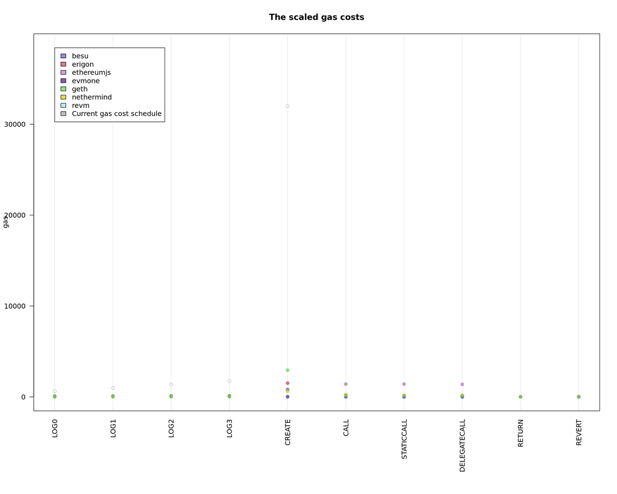

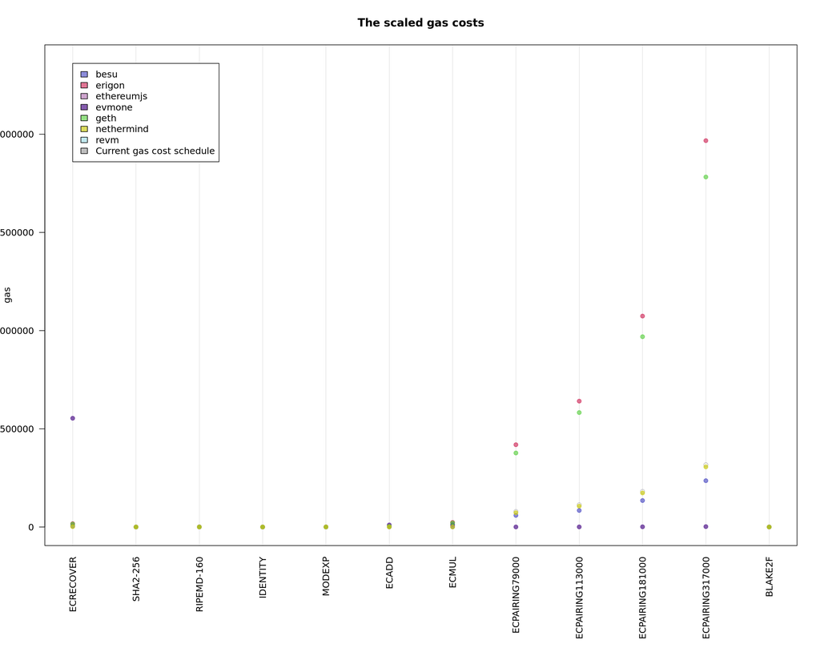

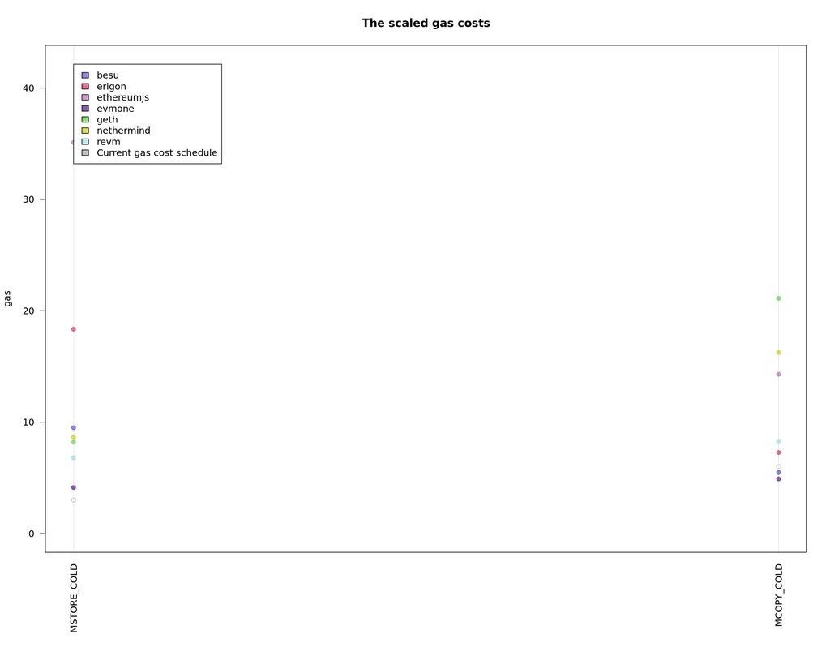

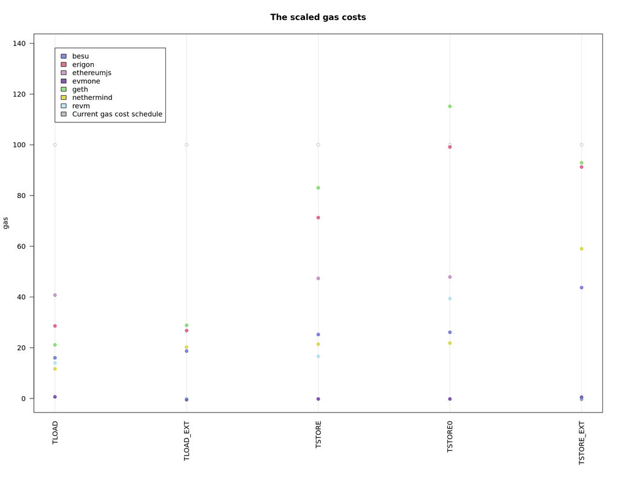

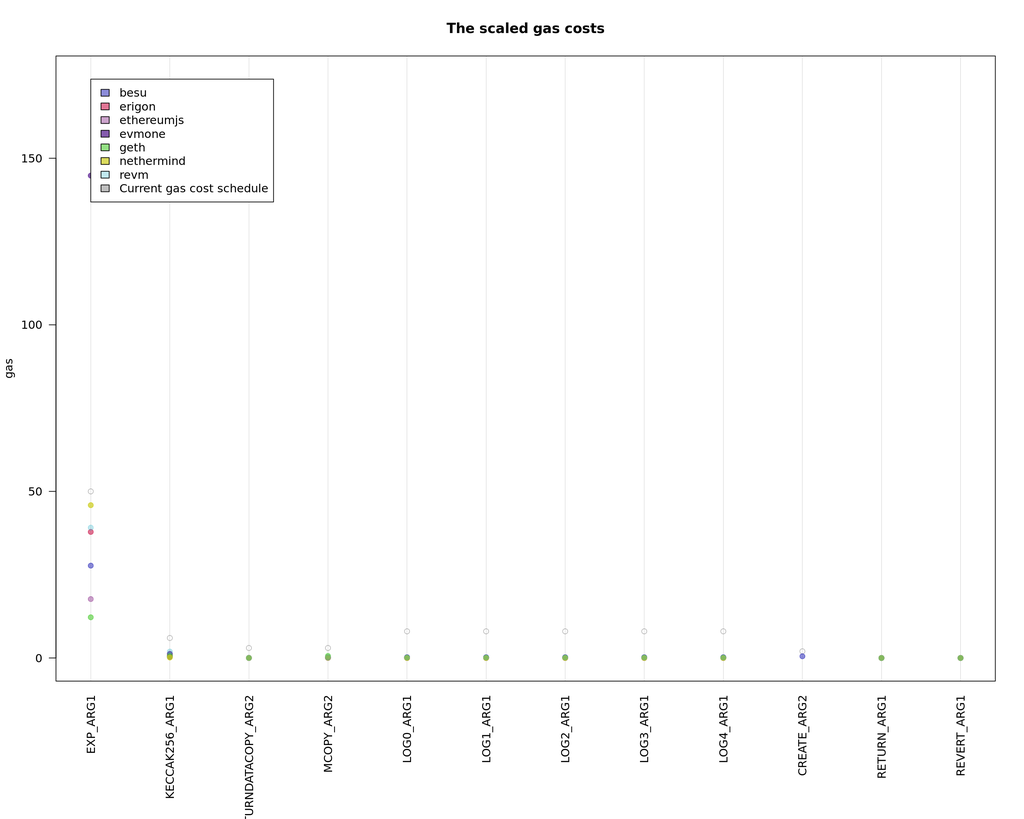

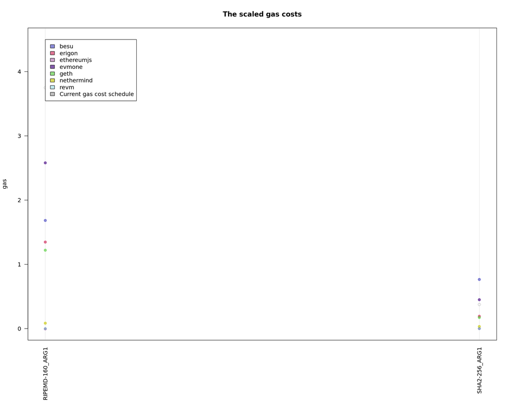

```r
for (g in 0:max_groups) {
  groups_opcode <- current_gas_cost[which(current_gas_cost$groups == g), "opcode"]
  if (length(groups_opcode) == 0) {
    next
  }
  grups_gas_schedule_comparison <- gas_schedule_comparison[which(gas_schedule_comparison$opcode %in% groups_opcode), ]
  if (nrow(grups_gas_schedule_comparison) == 0) {
    next
  }
  maximum_gas_cost = max(grups_gas_schedule_comparison[, c(all_envs_cols, "constant_current_gas")], na.rm=TRUE)
  par(mar=c(10, 4, 4, 2) + 0.1) # default is c(5, 4, 4, 2) + 0.1
  plot(grups_gas_schedule_comparison$constant_current_gas, col='grey', xaxt='n', ylim=c(0,maximum_gas_cost * 1.2), xlab="", ylab="gas", las=2)
  axis(1, at=1:nrow(grups_gas_schedule_comparison), labels=grups_gas_schedule_comparison$opcode, las=2, lwd=0.1, tck=1)
  for (i in 1:length(all_envs)) {
    points(grups_gas_schedule_comparison[, paste0(all_envs[i], "_gas")], col=env_colors[i], bg=env_colors[i], xaxt='n', pch=21)
  }
  title(main="The scaled gas costs")
  legend(1, maximum_gas_cost * 1.2, c(all_envs, "Current gas cost schedule"), fill=c(env_colors[1:length(all_envs)], 'grey'), cex=1)
}
```

Calculate and plot the alternative gas cost schedule. The calculated values are:

```r
gas_schedule_comparison[, c('opcode', 'constant_current_gas', 'alternative_gas', 'alternative_gas_stderr', 'alternative_gas_rel_diff', 'alternative_gas_rel_stderr')]
```

```
##                  opcode constant_current_gas alternative_gas
## 1                   ADD            3.000e+00    2.224481e+00
## 2                   MUL            5.000e+00    5.148461e+00
## 3                   SUB            3.000e+00    2.681923e+00
## 4                   DIV            5.000e+00    4.034828e+00
## 5                  SDIV            5.000e+00    6.659054e+00
## 6                   MOD            5.000e+00    4.443201e+00
## 7                  SMOD            5.000e+00    7.059396e+00
## 8                ADDMOD            8.000e+00    8.116796e+00
## 9                MULMOD            8.000e+00    1.391602e+01
## 10                  EXP            1.000e+01    2.658449e+01
## 11           SIGNEXTEND            5.000e+00    5.246848e+00
## 12                   LT            3.000e+00    2.252492e+00
## 13                   GT            3.000e+00    2.610156e+00
## 14                  SLT            3.000e+00    3.000000e+00
```

[output cut: 321 more lines]

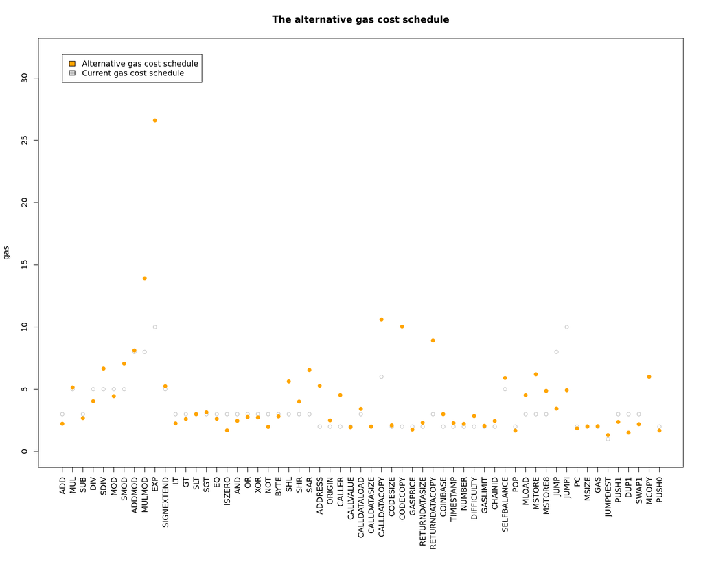

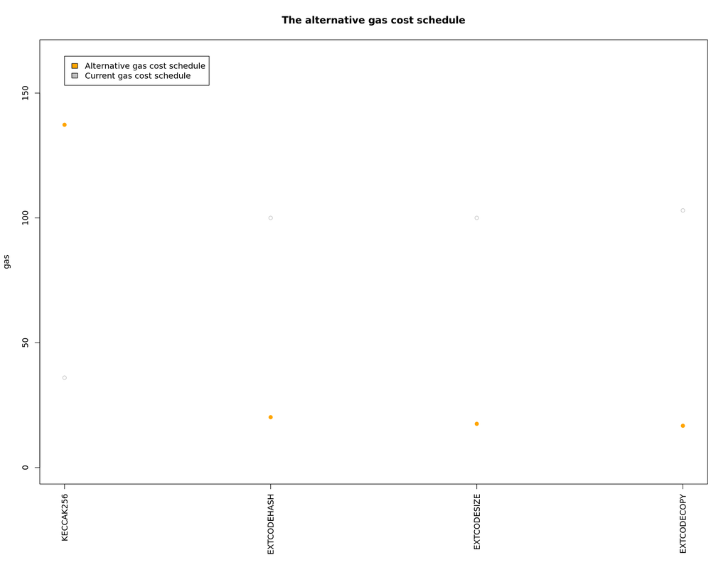

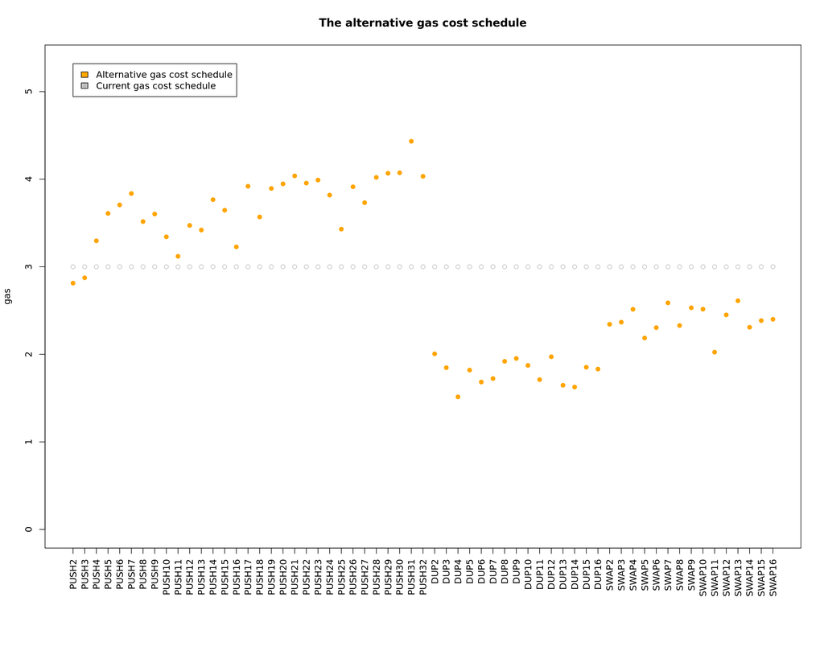

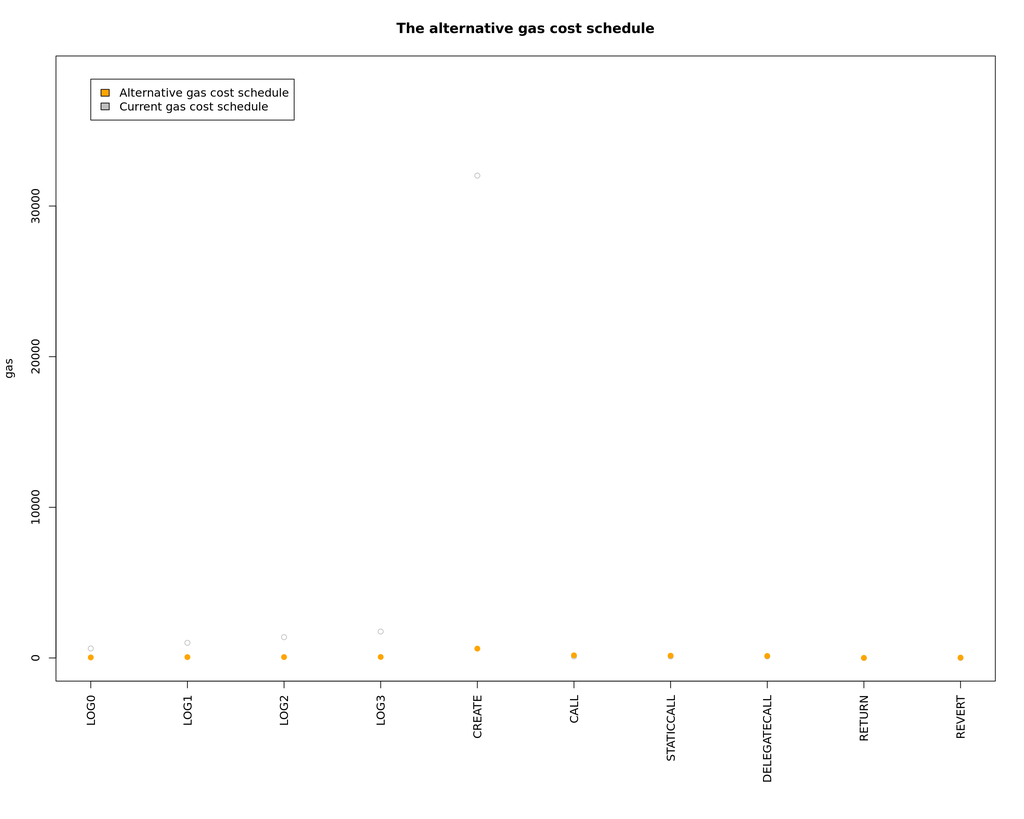

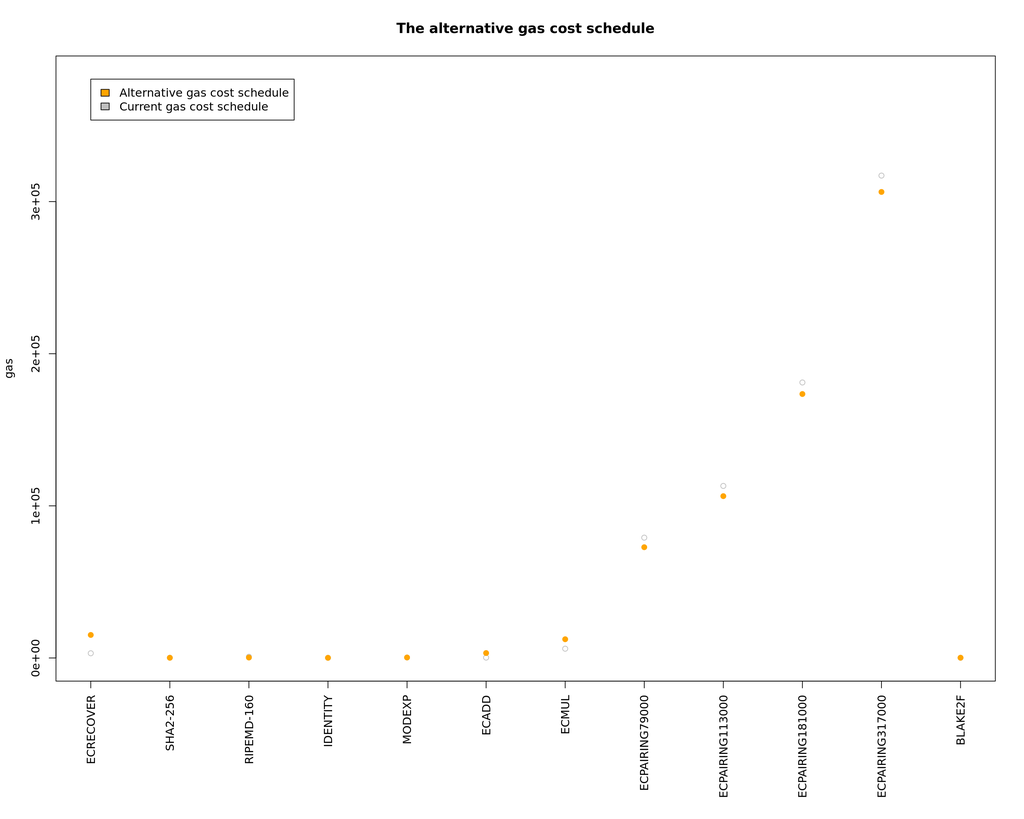

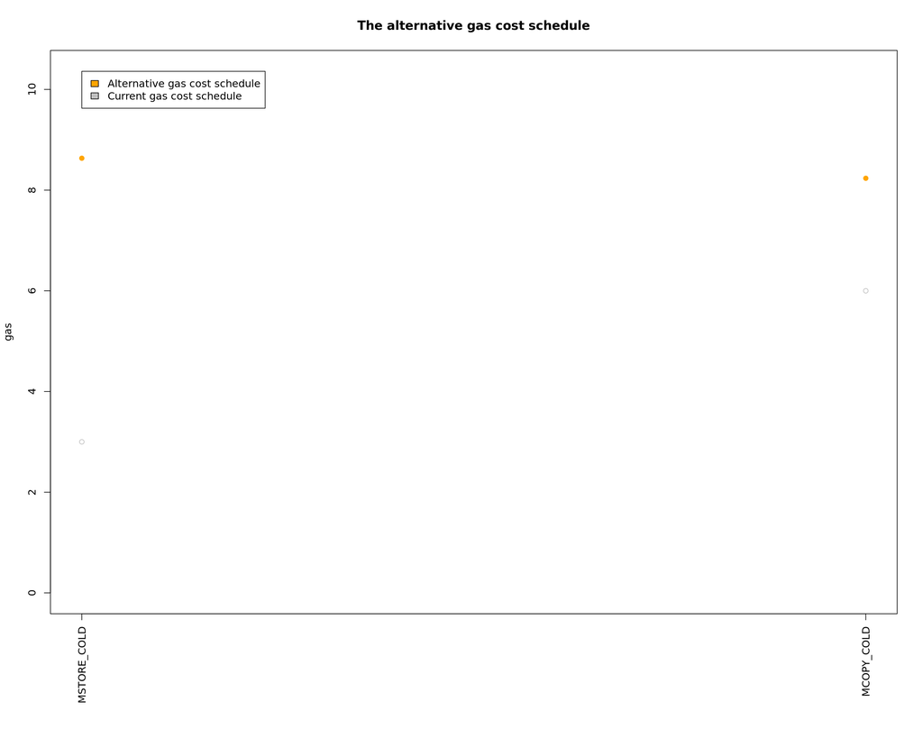

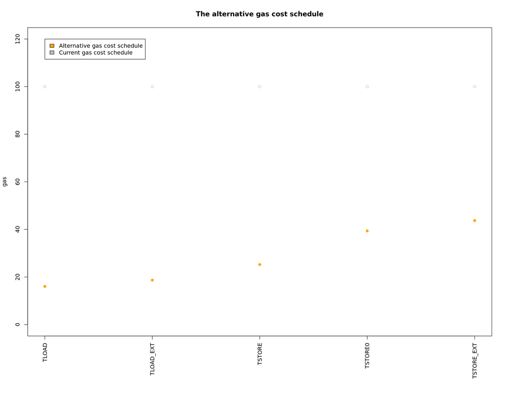

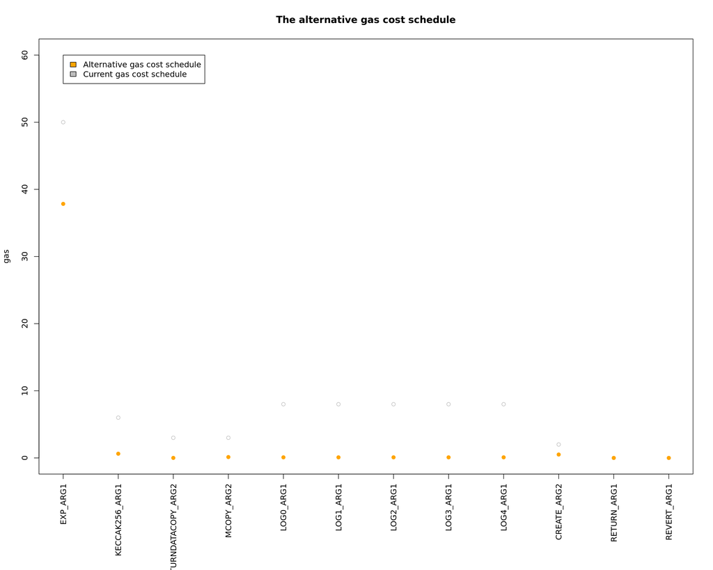

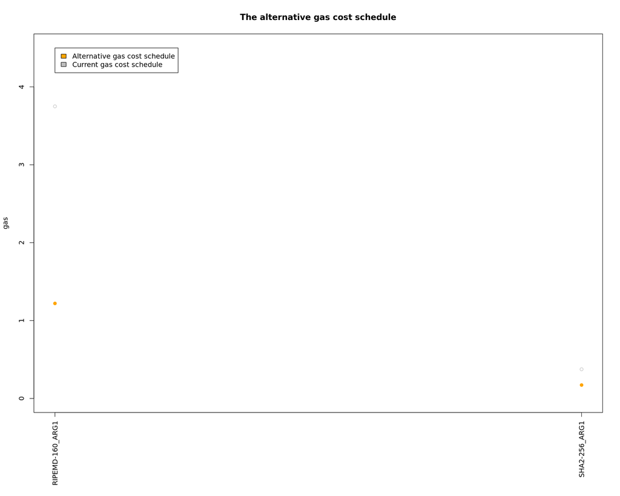

```r
for (g in 0:max_groups) {
  groups_opcode <- current_gas_cost[which(current_gas_cost$groups == g), "opcode"]
  if (length(groups_opcode) == 0) {
    next
  }
  grups_gas_schedule_comparison <- gas_schedule_comparison[which(gas_schedule_comparison$opcode %in% groups_opcode), c("opcode", "constant_current_gas", "alternative_gas")]
  if (nrow(grups_gas_schedule_comparison) == 0) {
    next
  }
  maximum_gas_cost = max(grups_gas_schedule_comparison[, c("constant_current_gas", "alternative_gas")], na.rm=TRUE)

  par(mar=c(10, 4, 4, 2) + 0.1) # default is c(5, 4, 4, 2) + 0.1
  plot(grups_gas_schedule_comparison$constant_current_gas, col='grey', xaxt='n', ylim=c(0,maximum_gas_cost * 1.2), xlab="", ylab="gas")
  axis(1, at=1:nrow(grups_gas_schedule_comparison), labels=grups_gas_schedule_comparison$opcode, las=2)
  points(grups_gas_schedule_comparison$alternative_gas, col='orange', bg='orange', xaxt='n', pch=21)
  title(main="The alternative gas cost schedule")
  legend(1, maximum_gas_cost * 1.2, c("Alternative gas cost schedule", "Current gas cost schedule"), fill=c('orange', 'grey'), cex=1)
}
```